Time Series in R

# Notes from “Intoductory Time Series with R” by Paul S.P. Cowpertwait · Andrew V. Metcalfe

## Plots, trends and seasonal variation, A flying start: Air Passenger Bookings

```r
data("AirPassengers")

AP <- AirPassengers

AP
```

```
##      Jan Feb Mar Apr May Jun Jul Aug Sep Oct Nov Dec
## 1949 112 118 132 129 121 135 148 148 136 119 104 118
## 1950 115 126 141 135 125 149 170 170 158 133 114 140
## 1951 145 150 178 163 172 178 199 199 184 162 146 166
## 1952 171 180 193 181 183 218 230 242 209 191 172 194
## 1953 196 196 236 235 229 243 264 272 237 211 180 201
## 1954 204 188 235 227 234 264 302 293 259 229 203 229
## 1955 242 233 267 269 270 315 364 347 312 274 237 278
## 1956 284 277 317 313 318 374 413 405 355 306 271 306
## 1957 315 301 356 348 355 422 465 467 404 347 305 336
## 1958 340 318 362 348 363 435 491 505 404 359 310 337
## 1959 360 342 406 396 420 472 548 559 463 407 362 405
## 1960 417 391 419 461 472 535 622 606 508 461 390 432
```

```r
class(AP)
```

```
## [1] "ts"
```

```r
start(AP); end(AP); frequency(AP)
```

```
## [1] 1949    1
```

```
## [1] 1960   12
```

```
## [1] 12
```

```r
summary(AP)
```

```
##    Min. 1st Qu.  Median    Mean 3rd Qu.    Max.
##   104.0   180.0   265.5   280.3   360.5   622.0
```

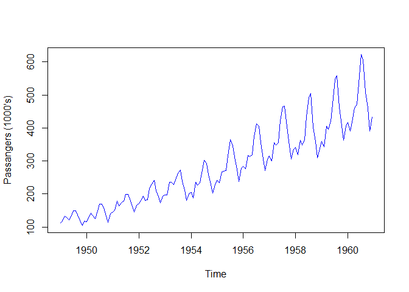

```r
plot(AP, ylab="Passangers (1000's)", col = "blue")
```

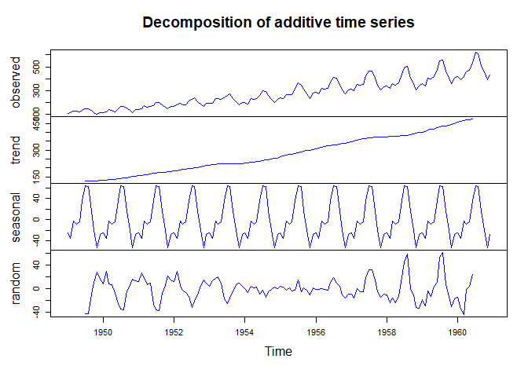

```r
plot(decompose(AP), col = "blue")
```

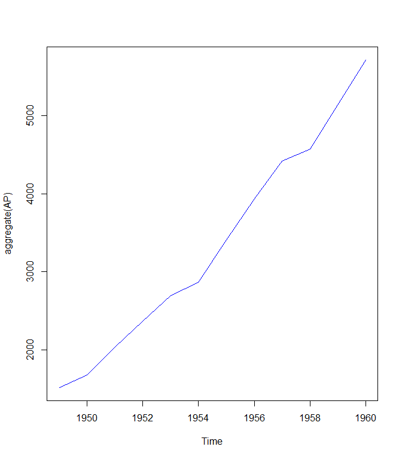

```r
plot(aggregate(AP), col ="blue")
```

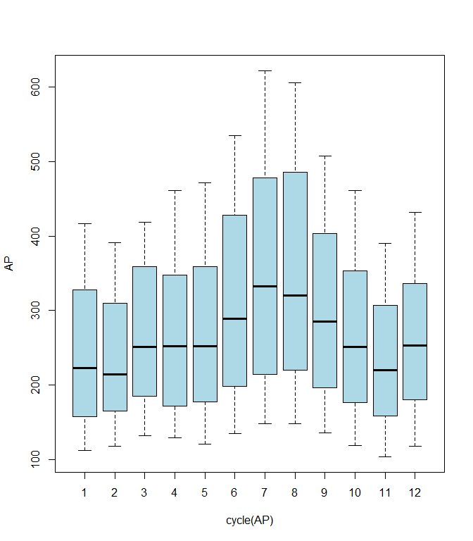

```r
boxplot(AP ~ cycle(AP), col = "lightblue")
```

## Umemployment: Maine

Data can be found [here.](https://github.com/svkerr/R_Files/blob/master/TimeSeries/Maine.dat)

```r
# Aquire data
Maine.month <- read.csv("~/Coding Stuff/R code/timeSeriesR/Maine.txt", sep="", stringsAsFactors=FALSE)

attach(Maine.month)
class(Maine.month)
```

```
## [1] "data.frame"
```

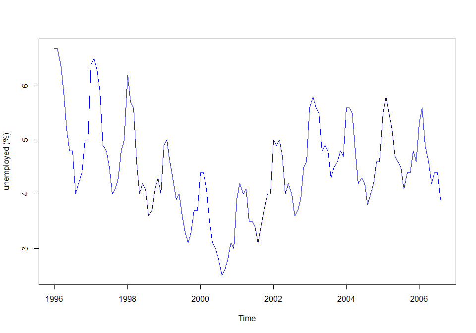

```r
# Lets convert this from a dataframe to a timeseries
Maine.month.ts <- ts(unemploy, start = c(1996, 1), freq = 12)
Maine.annual.ts <- aggregate(Maine.month.ts)/12

plot(Maine.month.ts, ylab = "unemployed (%)", col = "blue")
```

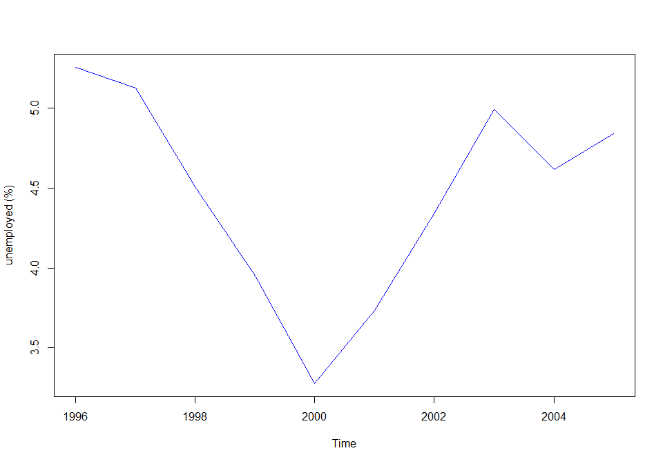

```r
plot(Maine.annual.ts, ylab = "unemployed (%)", col = "blue")
```

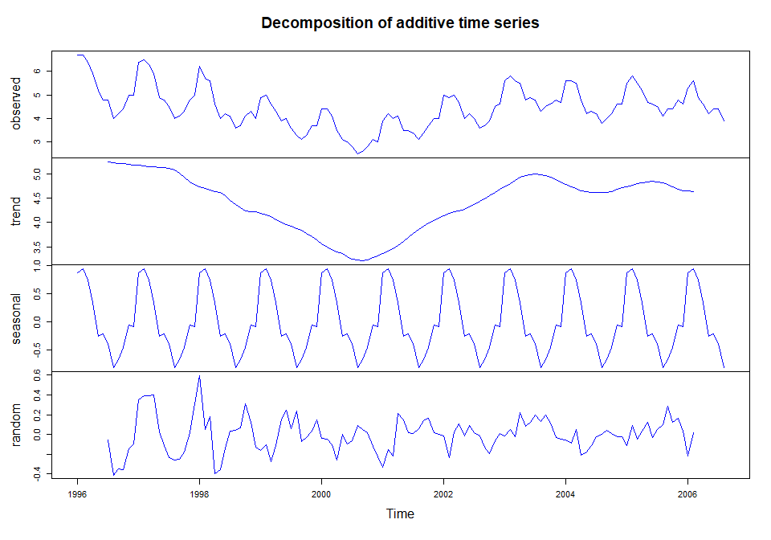

```r
plot(decompose(Maine.month.ts), col = "blue")
```

```r
Maine.Feb <- window(Maine.month.ts, start = c(1996, 2), freq = TRUE)
Maine.Aug <- window(Maine.month.ts, start = c(1996, 8), freq = TRUE)

Feb.ratio <- mean(Maine.Feb) / mean(Maine.month.ts)
Aug.ratio <- mean(Maine.Aug) / mean(Maine.month.ts)

Feb.ratio
```

```
## [1] 1.222529
```

```r
Aug.ratio
```

```
## [1] 0.8163732
```

On average, unemployment is 22% higher in February and 18% lower in August. An explanation is that Maine attracts tourists during the summer, and this creates more jobs. Also, the period before Christmas and over the New Year’s holiday tends to have higher employment rates than the first few months of the new year.

## Multiple Time Series: Electricity, Beer and Chocolate data

Here we illustrate a few important ideas and concepts related to multiple time series data. The monthly supply of electricity (millions of kWh), beer (Ml), and chocolate-based production (tonnes) in Australia over the period January 1958 to December 1990 are available from the Australian Bureau of Statistics (ABS)

```r
CBE <- read.delim("~/Coding Stuff/R code/timeSeriesR/cbe.dat")
CBE[1:4, ]
```

```
##   choc beer elec
## 1 1451 96.3 1497
## 2 2037 84.4 1463
## 3 2477 91.2 1648
## 4 2785 81.9 1595
```

```r
class(CBE)
```

```
## [1] "data.frame"
```

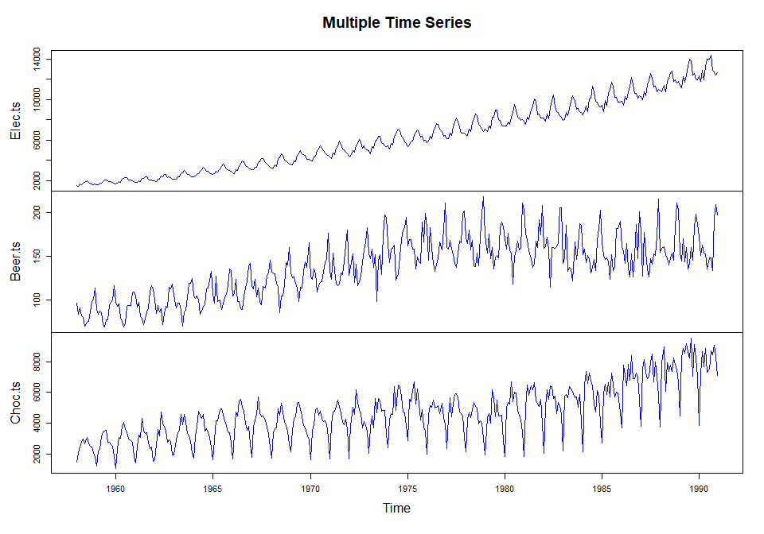

```r
Elec.ts <- ts(CBE[, 3], start = 1958, freq = 12)
Beer.ts <- ts(CBE[, 2], start = 1958, freq = 12)
Choc.ts <- ts(CBE[, 1], start = 1958, freq = 12)

plot(cbind(Elec.ts, Beer.ts, Choc.ts), main = "Multiple Time Series", col = "blue")
```

Intersection between the air passenger data and the electricity data is obtained as follows:

```r
# Calculate the intersection of the two datasets
AP.elec <- ts.intersect(AP, Elec.ts)

# Sanity check the data
start(AP.elec)
```

```
## [1] 1958    1
```

```r
end(AP.elec)
```

```
## [1] 1960   12
```

```r
AP.elec[1:3, ]
```

```
##       AP Elec.ts
## [1,] 340    1497
## [2,] 318    1463
## [3,] 362    1648
```

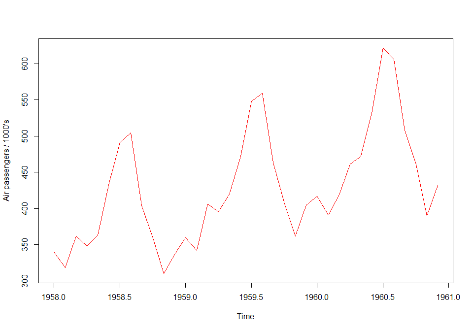

```r
AP <- AP.elec[, 1]; Elec <- AP.elec[, 2]

#Compare the two plots
plot(AP, main = "", ylab = "Air passengers / 1000's", col = "red")
```

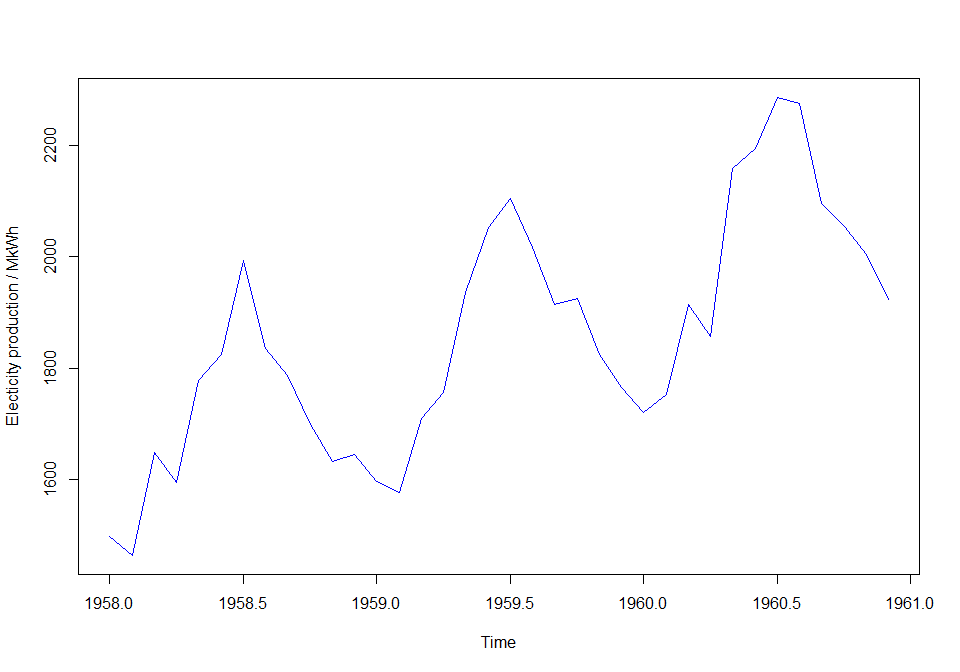

```r
plot(Elec, main = "", ylab = "Electicity production / MkWh", col = "blue")
```

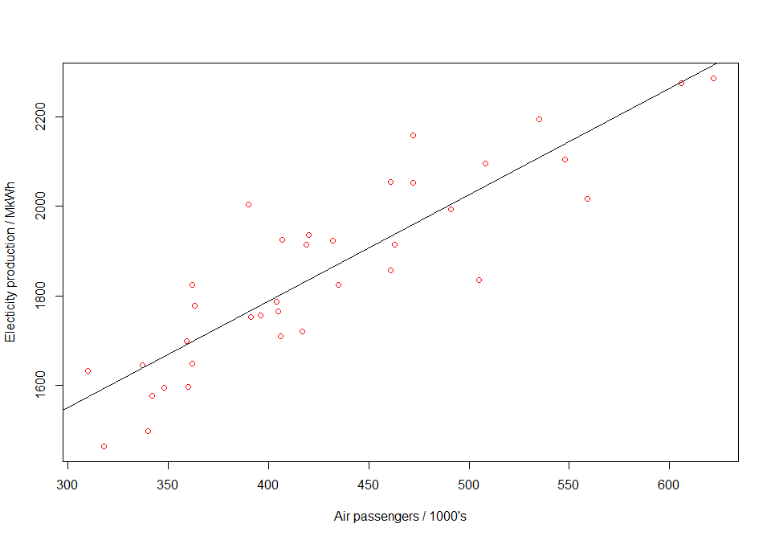

```r
# Compare them against eachother
plot(as.vector(AP), as.vector(Elec),
     xlab = "Air passengers / 1000's",
     ylab = "Electicity production / MkWh",
     col = "red")

# Add regression line
abline(reg = lm(Elec ~ AP))
```

```r
# Calculate the correlation
cor(AP, Elec)
```

```
## [1] 0.8841668
```

The result of these plots have no real meaning mind you. Air travel in the US has no causal relationship to Electricity consumption in Australia. Both plots have a increasing trend and an evident seasonal cycle, but like putting a kiwi next to a potato, if you squint really hard, sure they look similar, but they stil have nothing to do with eachother. **Remember this.**

## Quarterly exchange rate: GBP to NZ dollar

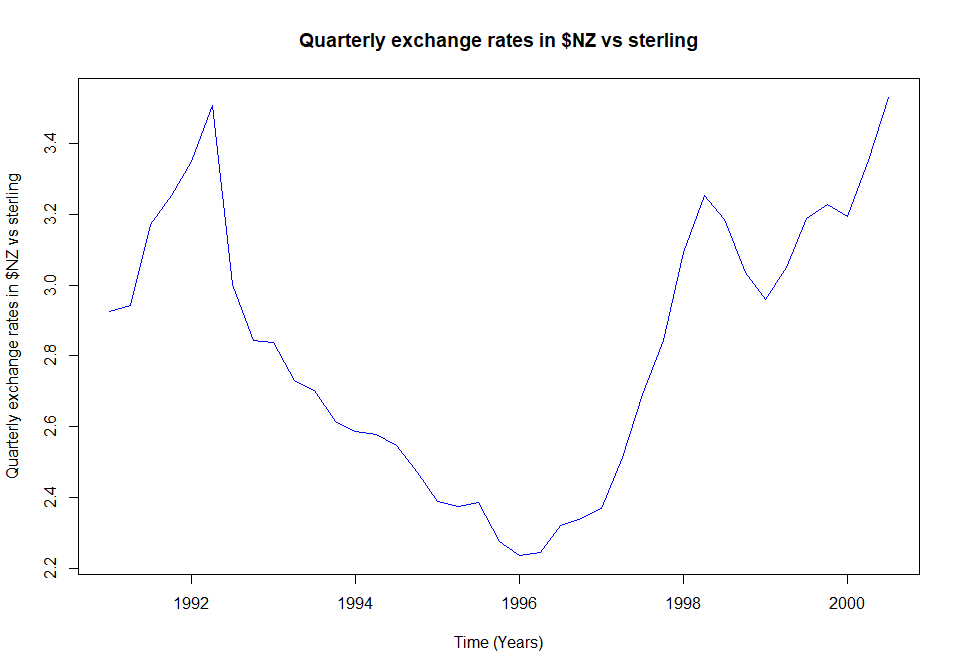

```r
Z <- read.csv("~/Coding Stuff/R code/timeSeriesR/pounds_nz.dat", sep="", stringsAsFactors=FALSE)
Z.ts <- ts(Z, start = 1991, freq= 4)

plot(Z.ts, xlab = "Time (Years)", ylab = "Quarterly exchange rates in $NZ vs sterling", main="Quarterly exchange rates in $NZ vs sterling", col = "blue")
```

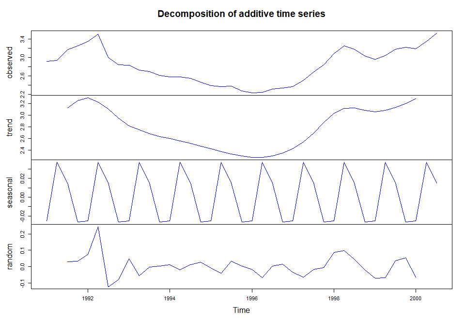

```r
plot(decompose(Z.ts), col = "blue")
```

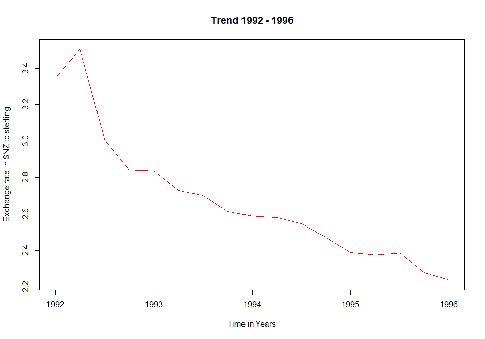

```r
# Sub set the data to view two major trends
## One from 1992-1996
## One from 1996-1998
z.92.96 <- window(Z.ts, start = c(1992, 1), end = c(1996, 1))
z.96.98 <- window(Z.ts, start = c(1996, 1), end = c(1998, 1))

plot(z.92.96, ylab = "Exchange rate in $NZ to sterling",
     xlab = "Time in Years", col = "red", main = "Trend 1992 - 1996")
```

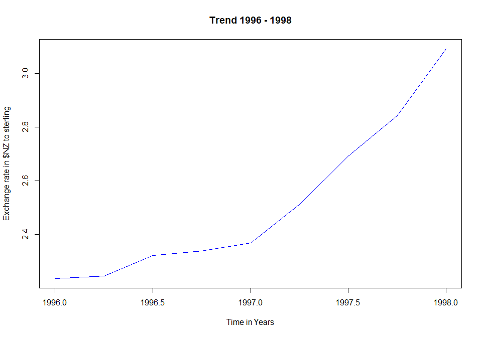

```r
plot(z.96.98, ylab = "Exchange rate in $NZ to sterling", main = "Trend 1996 - 1998",
     xlab = "Time in Years", col = "blue")
```

## Global Temperature Series

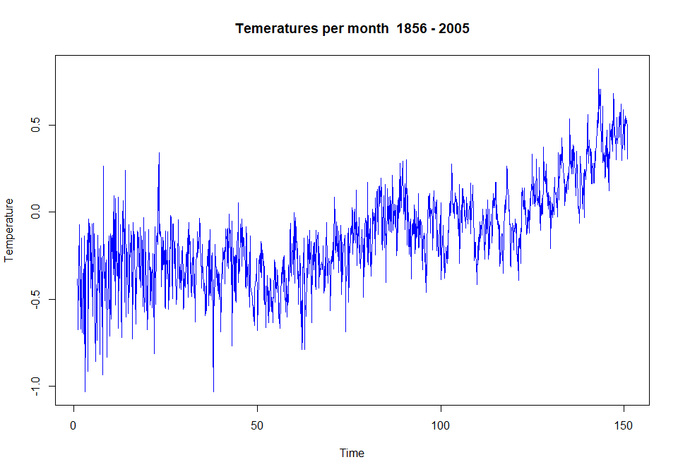

```r
# Fix the buggered version of the dataset I found
global <- read.table("~/Coding Stuff/R code/timeSeriesR/global.dat", quote="\"", comment.char="", stringsAsFactors=FALSE)

# convert the rows to columns using a vector transpose
colN <- list()
for(i in 1:nrow(global)) {
  colN[[i]] <- t(global[i, ])
}

# unlist the 150 columns and make one massive column
long_dataframe <- data.frame(d = unlist(colN, use.names = FALSE))
global<- long_dataframe
names(global) <- c("Temperature")
global.ts <- ts(global, freq = 12)
global.annual <- aggregate(global.ts, FUN = mean)

plot(global.ts, col = "blue", main = "Temeratures per month  1856 - 2005")
```

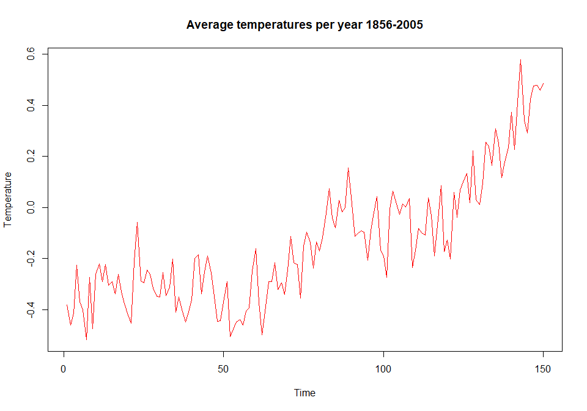

```r
plot(global.annual, col = "red", main = "Average temperatures per year 1856-2005")
```

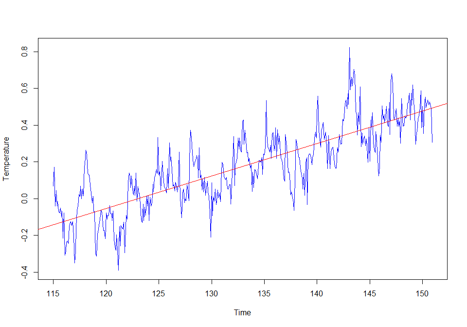

```r
new.series <- window(global.ts, start=c(115, 1), end = c(150, 12))
new.time <- time(new.series)
plot(new.series, col = "blue");abline(reg=lm(new.series ~ new.time), col="red")
```

## Decomposition of a series

A time series of length $n$ is represented by:

$$\{x_t~:~t~=~1,2,...,n\}~=~\{x_1,x_2,...x_n\}$$
This consists of $n$ values, sampled at discrete times $1, 2, ..., n$. This will be denoted as $\{x_t\}$ when the length $n$ of the series does note need to be specified.

The time series model is a sequence of random variables and the observed time series is considered a realisation from the model.

We use the same notation for both and rely on the context to make the distinction.

An overline is used to denote the **sample means**:

$$\bar{x} = \sum{\frac{x_i}{n}}$$

The “hat” will be usde to denote the **prediction** or the **forcast**.

For example, with the series $\{x_t~:~t=1,...n\}~, ~\hat{x}_{t+k|t}$ is the forecast made at time $t$ for a future value at time $t + k$.

A forecast is a predicted future value and the number of timesteps into the future is the **lead time ($k$)**

Following the convention for timeseries notation $\hat{x}_{t+k|t}$ can either be the numeric prediction or the random variable depending on the context.

## Models

As the first two examples showed, many series are dominated by a trend and/or seasonal effects, so the models in this section are based on these components. A simple **additive decomposition** model is given by:

$$x_t = m_t + s_t + z_t$$

Where at a time $t$:

- $x_t$ is the **observed series**
- $m_t$ is the **trend**
- $s_t$ is the **seasonal effect**
- $z_t$ is an **error term** that is in general, a sequence of correlated random variables with mean equal to zero

In theis section we will cover approaches to extracting the trend $m_t$ and the seasonal effect $s_t$ in `R`.

If the seasonal effect tends to **increase as the trend increases**, a multiplicative model may be more appropriate:

$$x_t = m_t . s_t + z_t$$

If the random variation is modelled by a multiplicative factor and the variable is positive, an aditive decomposition model for $log(x_t)$ can be used:

$$log(x_t) = m_t + s_t + z_t$$
If the random series $z_t$ are normally distributed with a mean $0$ and a variance $\sigma^2$, then the predicted mean value at time $t$ based on the equation above, is given by:

$$\hat{x_t} = e^{m_t + s_t}e^{0.5\sigma^2}$$

## Estimating trends and seasonal effects

There are various ways to estimate the trend $m_t$ at time $t$, but a relatively simple procedure, which is available in `R` and does not assume any specific form is to calculate a **moving average** centered on $x_t$.

A moving average is an average of a specified number of time series values around each value in the time series, with the exception of the first and last few terms. In this context, the length of the moving average is chosen to average out athe seasonal effects which can be estimated later.

To average out seasonal effects with integer number of moving averages, we need to center the moving average. This is done by averaging January up to December then averaging Feburary ($t=2$) up to January ($t=13$). This average og the two movign averages corresponds to $t=7$.

The trend at time $t$ can be estimated by the centered moving average:

$$\hat{m_t} = \frac{\frac{1}{2}x_{t-6} + x_{t-5}+ ... +x_{t-1} + x_{t}+ x_{t+1} + x_{t-+5}+\frac{1}{2}x_{t+6}}{12}$$

where $t=7,...,n-6$

An estimate for the **monthly additive effect**($s_t$) at time $t$ can be obtained by subtracting $\hat{m_t}$:

$$\hat{s_t} = x_t - \hat{m_t}$$

If the monthly effect is multiplicative, the estimate is given by division:

$$\hat{s_t} = \frac{x_t}{\hat{m_t}}$$

## Decomposition in `R`

The `stl()` function stands for **Seasonal Decomposition of Time Series by Loess**, and is used to decompose a time series into seasonal, trend and irregular components using loess.

The `decompose()` function will decompose an additive timeseries by default. By specifying the `type = "mult"` argument, it will use a multiplicative model.

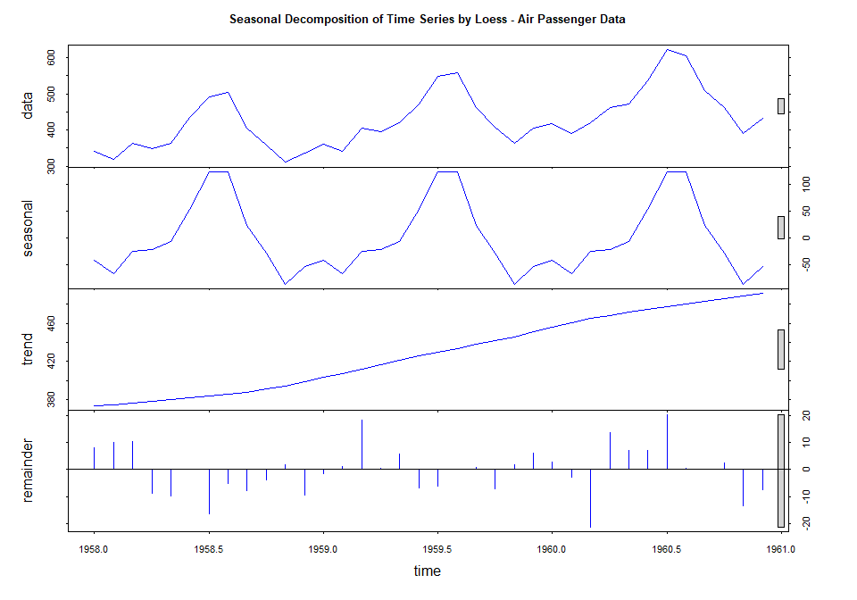

```r
plot(stl(AP, s.window = "periodic"), main = "Seasonal Decomposition of Time Series by Loess - Air Passenger Data", col = "blue")
```

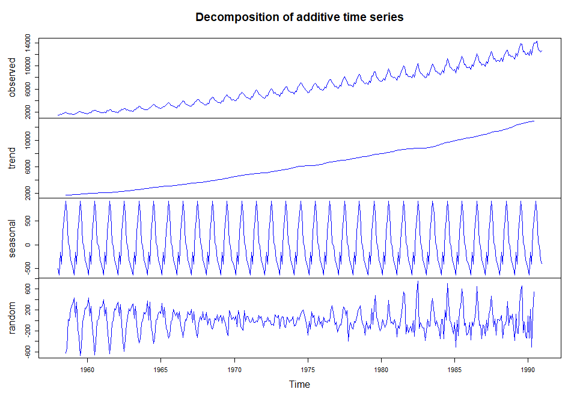

```r
plot(decompose(Elec.ts), col = "blue")
```

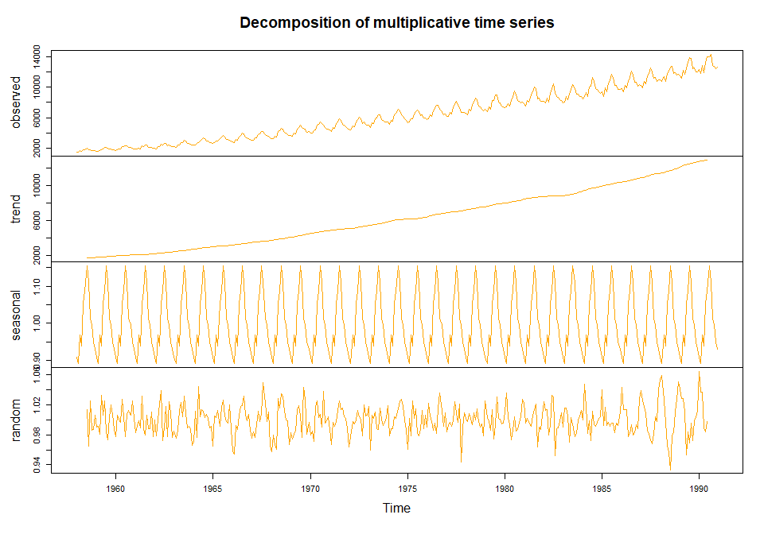

```r
Elec.decom <- decompose(Elec.ts, type = "mult")
plot(Elec.decom, col = "orange")
```

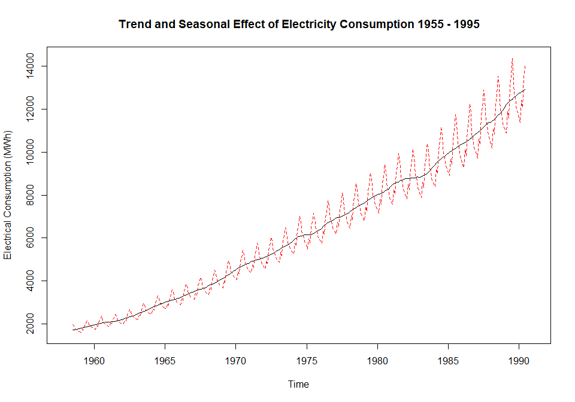

```r
Trend <- Elec.decom$trend
Seasonal <- Elec.decom$seasonal
Random <- Elec.decom$random
ts.plot(cbind(Trend, Trend*Seasonal), lty = 1:2, col = 1:2,ylab = "Electrical Consumption (MWh)", main = "Trend and Seasonal Effect of Electricity Consumption 1955 - 1995")
```

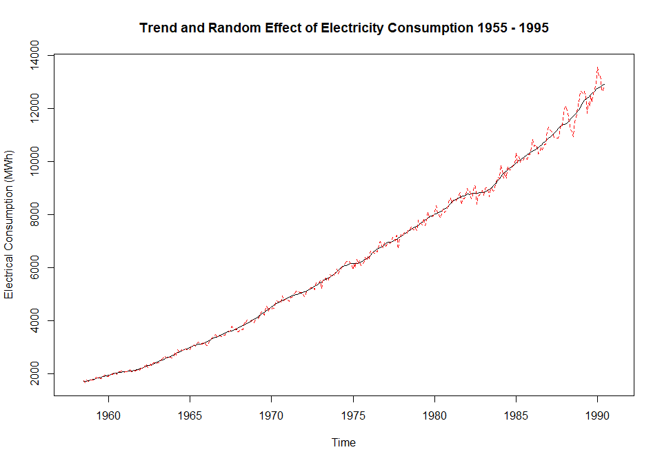

```r
ts.plot(cbind(Trend, Trend*Random), lty = 1:2, col = 1:2,ylab = "Electrical Consumption (MWh)", main = "Trend and Random Effect of Electricity Consumption 1955 - 1995")
```

## Exercises

- Carry out the following exploratory time series analysis in `R` using either the chocolate or the beer production data.
  - Produce a time plot of the data. Plot the aggregated annual series and a boxplot that summarises the observed values for each season, and comment on the plots.
  - Decompose the series into the components trend, seasonal effect, and residuals, and plot the decomposed series. Produce a plot of the trend with a superimposed seasonal effect.

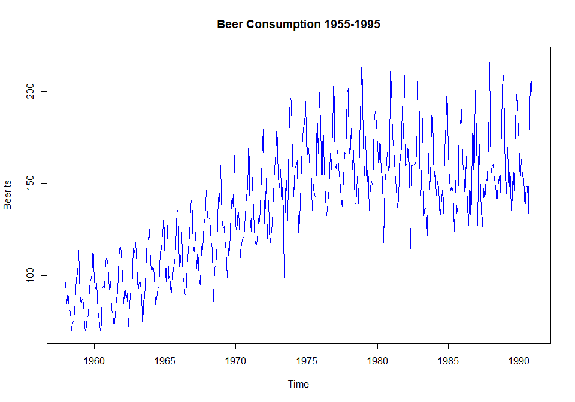

```r
plot(Beer.ts, col = "blue", main = "Beer Consumption 1955-1995")
```

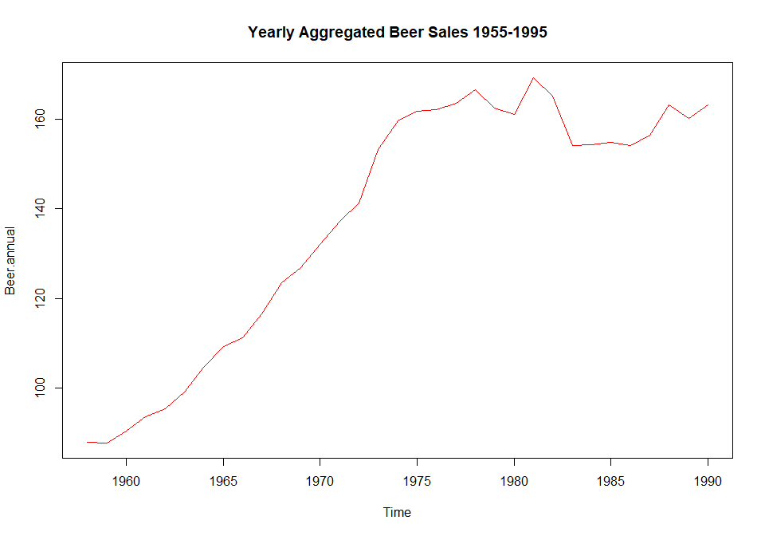

```r
Beer.annual <- aggregate(Beer.ts, FUN = mean)
plot(Beer.annual, main = "Yearly Aggregated Beer Sales 1955-1995", col = "red")
```

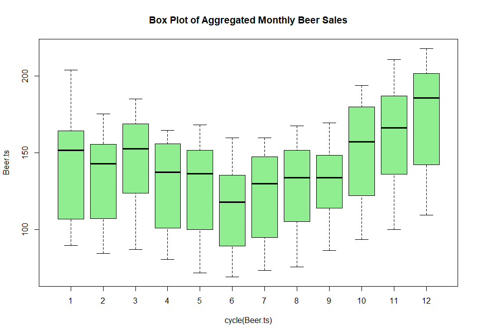

```r
boxplot(Beer.ts ~ cycle(Beer.ts), col = "lightgreen", main = "Box Plot of Aggregated Monthly Beer Sales")
```

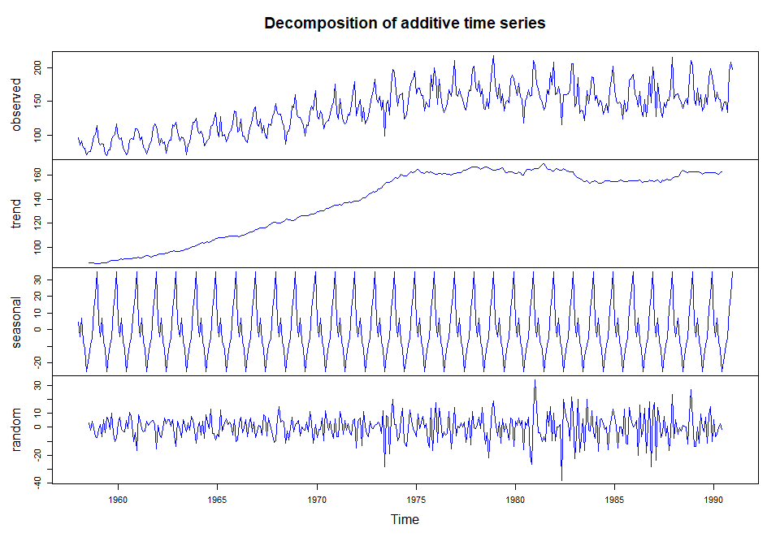

```r
plot(decompose(Beer.ts), col = "blue")
```

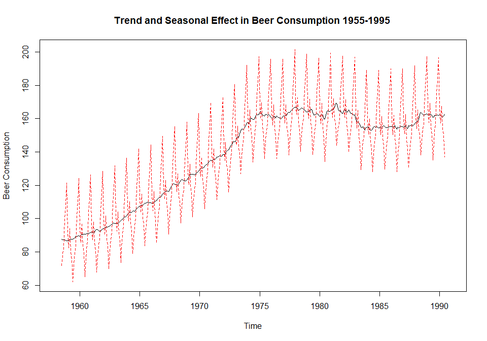

```r
Beer.decomp <- decompose(Beer.ts)

ts.plot(cbind(Beer.decomp$trend, Beer.decomp$seasonal+Beer.decomp$trend), lty = 1:2, col = 1:2, ylab ="Beer Consumption", main = "Trend and Seasonal Effect in Beer Consumption 1955-1995 ")
```

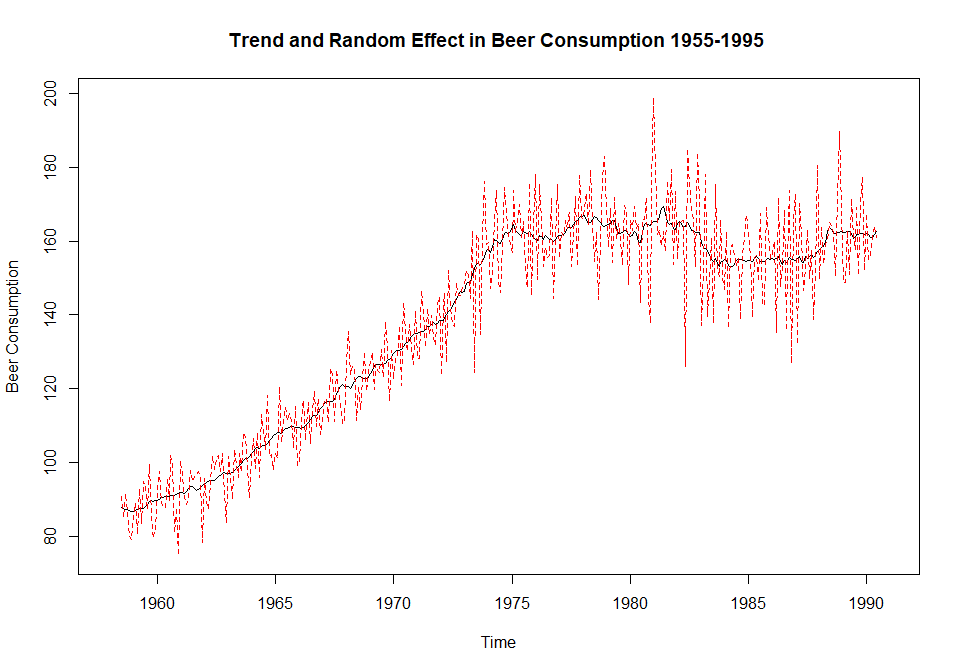

```r
ts.plot(cbind(Beer.decomp$trend, Beer.decomp$random+Beer.decomp$trend), lty = 1:2, col = 1:2, ylab ="Beer Consumption", main = "Trend and Random Effect in Beer Consumption 1955-1995 ")
```

# Correlation

## Expectation and the Ensemble

## Expected Value

The **expected value** (Expectation ($E$)) of a variable or of a function of of a variable, is its **mean** value in a population.

So $E(x)$ is the mean of $x$, denoted $\mu$ and $E[(x-\mu)^2]$ is the mean of the squared deviations about $\mu$, better known as the **variance** $\sigma^2$ of $x^2$.

The standard deviation $\sigma$ is the square root of the variance. Ifthere are two variables (x,y), the variance may be generalised to the **covariance**, $\gamma(x,y)$.

## Covariance

Covariance is defined by:

$$\gamma(x,y) = E[(x-\mu_x)(y-\mu_y)]$$

The covariance is a measure of **linear association** between two variables $(x, y)$. Importantly, a linear association between variables does not imply causality.

Sample estimates are obtained by adding the appropriate function of the individual data values and division by $n$, or in the case of variance and covariance, $n-1$, to give unbiased estimators.

For example, if we have $n$ data pairs, $(x_i, y_i)$, the sample covariance is given by:

$$Cov(x, y) = \sum ~ \frac{(x_i - \bar{x})(y_i - \bar{y})}{(n-1)}$$

If these data points are plotted, the lines $x=\bar{x}$ and $y=\bar{y}$ divide the plot into quadrants. Points in the lower left quadrant have both $(x_i - \bar{x})$ and $(y_i - \bar{y})$ negative, so the product that contributes to the covariance is positive. Points in the upper right quadrant also make a positive contribution.

The covariance can be calculated in `R` by using te `cov()` function.

```r
Herald <- read.delim("~/Coding Stuff/R code/timeSeriesR/Herald.dat", stringsAsFactors=FALSE)

# Manually calculate the covariance
x <- Herald$CO
y <- Herald$Benzoa
n <- length(x)

sum((x-mean(x))*(y-mean(y)))/(n-1)
```

```
## [1] 5.511042
```

```r
# Just use the Cov function
cov(x, y)
```

```
## [1] 5.511042
```

```r
# Calculate the sample correlation
cor(x, y)
```

```
## [1] 0.3550973
```

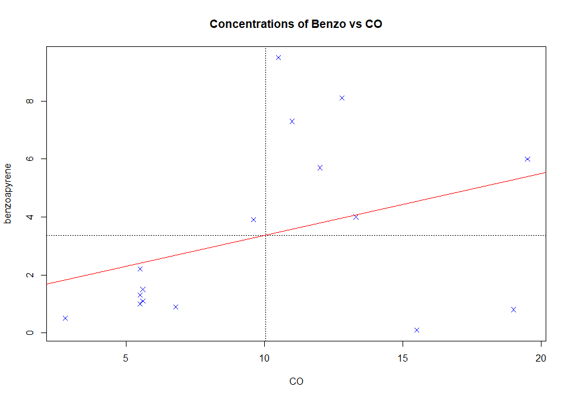

```
## integer(0)
```

```r
# Take a quick look
plot(x, y , xlab = "CO", ylab = "benzoapyrene", col = "blue", main = "Concentrations of Benzo vs CO", pch =4) +
  abline(h=(mean(y)), lty = 3) +
  abline(v=(mean(x)), lty = 3) +
  abline(lm(y ~ x), col = "red")
```

## Correlation

**Correlation** is a dimensionless measure of the linear association between a pair of variables $(x,y)$ and is obtained by standardising the covariance by dividing it by the product of the standard deviations of the variables.

Correlation takes a value between -1 and 1, with a value of 0 indicating no linear association between the two.

The **popular correlation** $\rho$, between a pair of variables, is defined by:

$$\rho(x, y) = \frac{E[(x-\mu_x)(y-\mu_y)]}{\sigma_x \sigma_y} = \frac{\gamma(x,y)}{\sigma_x \sigma_y}$$

The sample correlation, $Cor$ is an estimate of $\rho$ and is calculated as:

$$Cor(x,y) = \frac{Cov(x,y)}{sd(x)sd(y)}$$

```r
# Calculate the correlation
cov(x, y) / (sd(x)*sd(y))
```

```
## [1] 0.3550973
```

```r
# Use the Cor() function
cor(x, y)
```

```
## [1] 0.3550973
```

Although the correlation is small, there is nevertheless a physical explanation for the correlation because both products are a result of incomplete combustion.

A correlation of 0.36 corresponds to a sligt visual impression that $y$ tends to increase as $x$ increases, despite the points being well scattered.

## The ensemble and stationarity

The mean function of a time series model is:

$$\mu(t) = E(x_t)$$

This is, in general a function of $t$. The expectation in this definition is an average taken across the **ensemble** of all the possible time series that might have been produced by the time series model.

The ensemble constitutes the entire population. If we have a time series model, we can simulate more than one time series.

However, with historical data, we usually only have a single time series so all we can do, without assuming a mathematical structure for the trend, is to estimate the mean at each sample point by the corresponding observed value.

In practice, we make estimates of any apparent trend and seasonal effects in our data and remove them, using `decompose()` for example, to obtain time series of the random component.

If the mean function is constant, we say that the time series model is **stationary** in the mean. The sample estimate of the **population mean** $\mu$, is the **sample mean** $\bar{x}$.

$$\bar{x} = \sum^{n}_{t=1}{\frac{x_t}{n}}$$
The equation above does rely on an assumption that a **sufficiently long** time series characterises the hypothetical model. Such models are known as **ergodic**, and the models in this book are all ergodic.

### Ergodic Series

A time series model that is stationary in the mean is ergodic in the mean if the time average for a single time series tends to the ensemble mean as the length of the time series increases:

$$\lim_{n \rightarrow \infty}~\frac{\sum{x_t}}{n} = \mu$$

### Variance function

The variance function of a time series model that is stationaty in the mean, is:

$$\sigma^2 (t) = E[(x_t - \mu)^2]$$

Which can, in principle, take a different value at every time $t$. But we cannot estimate variance at each time point from a single time series. To progress, we must make some simplfying assumption.

If we assume that the model is stationary in the variance, this **constant population variance** $\sigma^2$, can be estimated from the **sample variance**:

$$Var(x) = \frac{\sum(x_t - \bar{x})^2}{n-1}$$

In a time series analysis, sequential observations **may be correlated**. If the correlation is **positive**, $Var(x)$ will tend to **underestimate** the population variance in short series, as successive observations tend to be relatively similar.

In most cases, this does not present a problem, since the bias decreases rapidly as the length of $n$ increases.

### Autocorrelation

The mean and variance play an important role in the study of statistical distributions because they summarise two key distributional properties – a **central location** and the **spread**.

Similarly, in the study of time series models, a key role is played by the second-order properties, which include the **mean, variance,** and **serial correlation**.

> **Second order properties:**
> - **mean**
> - **variance**
> - **serial correlation**

Consider a time series model that is **stationary in the mean and the variance**. The variables may be correlated, and the model is **second-order stationary** if the correlation between variables depends **only on the number of time steps separating them**.

- The number of time steps between the variables is known as the **lag**.
- A correlation of a variable with itself at different times is known as **autocorrelation** or **serial correlation**.

If a time series model is second-order stationary, we can define an **autocovariance function** ($acvf$ ($\gamma_k$)), as a function of the **lag** $k$:

$$\gamma_k = E[(x_t - \mu)(x_{t+k} - \mu)]$$

The function $\gamma_k$ does not depend on $t$, because the expectation, which is across the ensemble, is the same at all times $t$. This definition follows naturally from the equation for variance, by replacing $x$ with $x_t$ and $x_{t+k}$ and noting that the mean $\mu$ is the main of both$x_t$ and $x_{t+k}$. The **lag autocorrelation function ($acf$ ($\rho_k$))** is defined by:

$$\rho_k = \frac{\gamma_k}{\sigma^2}$$

It follows from the definition that $\rho_0$ is 1.

The $acvf$ and $acf$ can be estimated from a time series by their sample equivalents. The sample $acvf$, $c_k$, is calculated as:

$$c_k = \frac{1}{n} \sum_{t=1}^{n-k} (x_t - \bar{x})(x_{t+k} - \bar{x})$$

Note that the autocovariance at lag 0, $c_0$, is the variance calculated with a denominator $n$. Also, a denominator $n$ is used when calculating $c_k$, although only $n-k$ terms are added to form the numerator.

The $acf$ is defined as:

$$r_k = \frac{c_k}{c_0}$$

We’ll demonstrate the calculations in R using a time series of wave heights (mm relative to still water level) measured at the centre of a wave tank. The **sampling interval is 0.1 second** and the record length is 39.7 seconds. The waves were generated by a wave maker driven by a **pseudo-random signal** that was programmed to emulate a rough sea. There is **no trend** and **no seasonal period**, so it is reasonable to suppose the time series is a realisation of a **stationary process**.

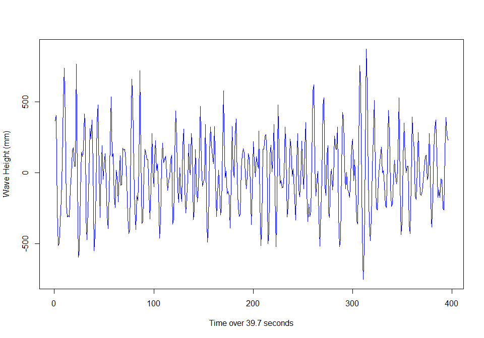

```r
#Load data
tank_data <- read.delim("~/Coding Stuff/R code/timeSeriesR/wave.dat")

#Convert to timeseries
plot(ts(tank_data), ylab = "Wave Height (mm)", xlab = "Time over 39.7 seconds", col = "blue")
```

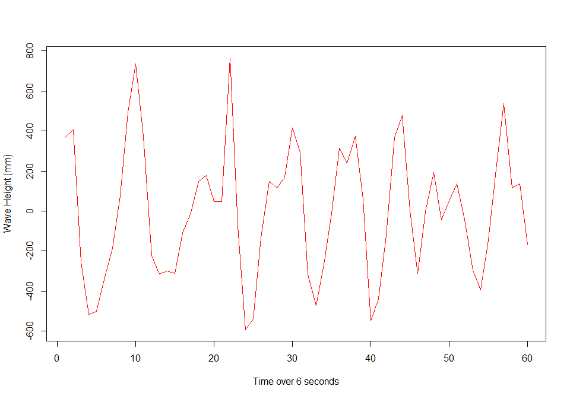

```r
plot(ts(tank_data$waveht[1:60]), ylab = "Wave Height (mm)",xlab = "Time over 6 seconds", col = "red")
```

The autocorrelations of $x$ are stored in the vector `acf(x)$acf`, with the lag $k$ autocorrelation located in `acf(x)$acf[k+1]`. For example, the lag 1 autocorrelation for the wave height is:

> `acf(waveht)$acf[2]`

The first entry `acf(waveht)$acf[1]` is $r_0$ and equals 1.

A **Scatterplot** complements the calculation of the correlation and alerts us to any **non-linear patterns**. In a similar way, we can draw a scatter plot corresponding to each autocorreltion. For example for lag 1, we could `plot(waveht[1:396], waveht[2:397])`.

Autocovariances are obtained by adding an argument to `acf`. The lag 1 autocovariance is given by:

`acf(waveht, type = c("covariance"))$acf[2]`

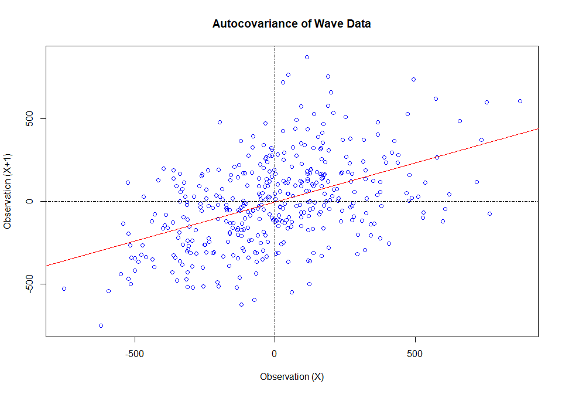

```
## integer(0)
```

```r
plot(tank_data$waveht[1:396], tank_data$waveht[2:397], xlab = "Observation (X)", ylab = "Observation (X+1)", col = "blue", main = "Autocovariance of Wave Data") +
  abline(lm(tank_data$waveht[1:396]~ tank_data$waveht[2:397]), col = "red") +
  abline(h =0, untf = FALSE, lty = 4) +
  abline(v =0, untf = FALSE, lty = 4)
```

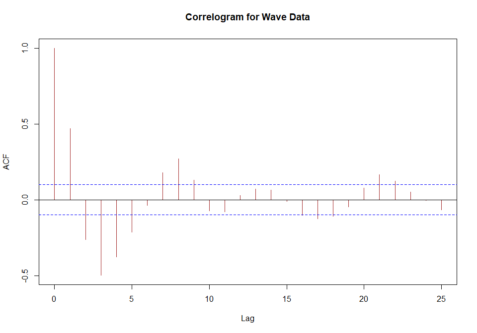

```
## [1] 0.4702564
```

```r
acf(tank_data$waveht, type = c("correlation"), col = "brown", main="Correlogram for Wave Data")$acf[2]
```

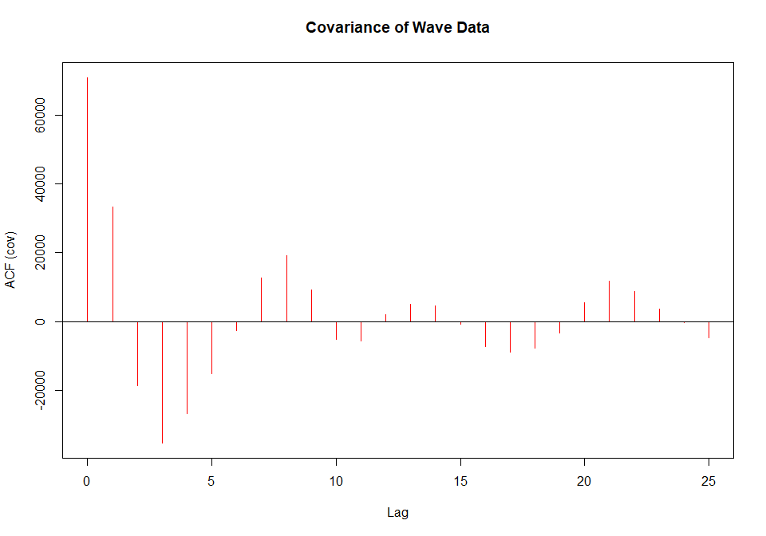

```
## [1] 33328.39
```

```r
acf(tank_data$waveht, type = c("covariance"), col = "red", main="Covariance of Wave Data")$acf[2]
```

The dotted lines on the correlogram are drawn at:

$$-\frac{1}{n} \pm \frac{2}{\sqrt{n}}$$
where:

- $-\frac{1}{n}$ is the **mean**
- $\frac{1}{n}$ is the **variance**

> If $r_k$ falls outside of these lines, we have evidence against the null hypothesis that $\rho_k=0$ at the $5\%$ level.

We have to be careful when interpreting muptiple hypothesis tests. Firstly, if $\rho_k$ does equal 0 at all lags $k$, then we would expect $5\%$ of the estimates $r_k$ to fall out side of the lines. Also, as the $r_k$ is correlated, we would expect the neighboring values to be statistically significant.

In the meantime, it is worth looking for statistically significant values at specific lags that have some practical meaning (for example, the lag that corresponds to the seasonal period, when there is one). For monthly series, a significant autocorrelation at lag 12 might indicate that the seasonal adjustment is not adequate.

## The Correlogram

The main use of the correlogram is to detect autocorrelations in the time series after we have removed an estimate of the trend and seasonal variation.

In the code below, the air passenger series is seasonally adjusted and the trend removed using `decompose()`. To plot the random component and draw the correlogram, we need to remember that one of the consequences of using a centered moving average of 12 months to smooth the time series (and thereby estimate the trend), is that the first and last six terms cannot be calculated.

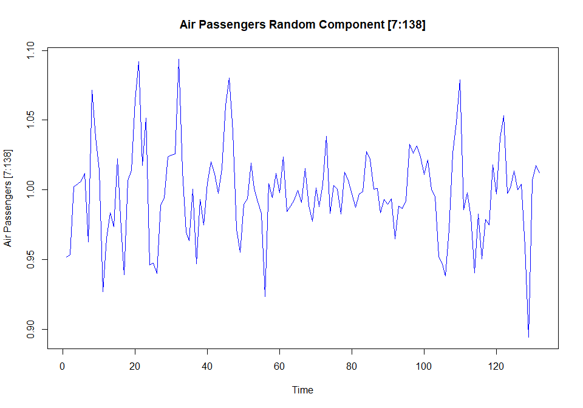

```r
# Load data
AP <- AirPassengers
# Decompose using a multiplicative model
AP.decom <- decompose(AP, "multiplicative")
# Convert decomposed random component to timeseries
plot(ts(AP.decom$random[7:138]), col = "blue", ylab = "Air Passengers [7:138]", main = "Air Passengers Random Component [7:138]")
```

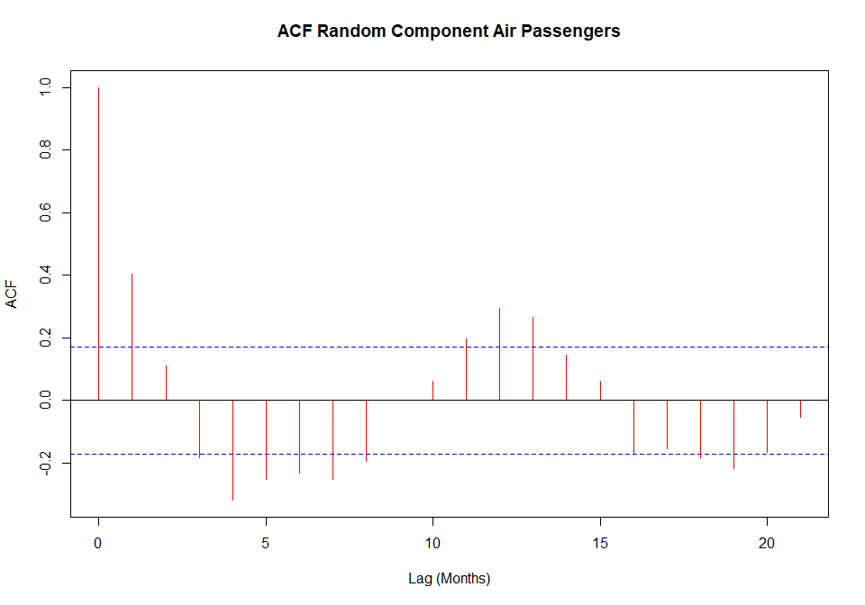

```r
# ACF of random component
acf(AP.decom$random[7:138], col = "red", xlab = "Lag (Months)", main="ACF Random Component Air Passengers")
```

```r
# Standard deviation of raw data
sd(AP[7:138])
```

```
## [1] 109.4187
```

```r
# Standard deviation of random component
sd(AP.decom$random[7:138])
```

```
## [1] 0.0333884
```

The **damped cosine** shape of the `acf()` is characteristic of an autoregressive model of order 2 or suggests that the seasonal adjustment has not been entirely effective. The latter explanation seems unlikely however, as the decomposition does estimate twelve independant monthly indicies.

The reduction in the standard deviation shows that the seasonal adjustment has been very effective.

# Forcasting Strategies

## Purpose

A very efficient method of forecasting one variable is to **find a related variable that leads it by one or more time intervals**. The closer the relationship and the longer the lead time, the better this strategy becomes. The trick is to find a suitable lead variable.

A second approach, common in marketing, is to use **information about the sales of similar products in the past**. The influential `Bass diffusion model` is based on this principle.

A third strategy is to make **extrapolations** based on present trends continuing and to implement adaptive estimates of these trends.

## Leading Variables and Associated Variables

The Australian Bureau of Statistics publishes detailed data on building approvals for each month, and, a few weeks later, the Building Activity Publication lists the value of building work done in each quarter.

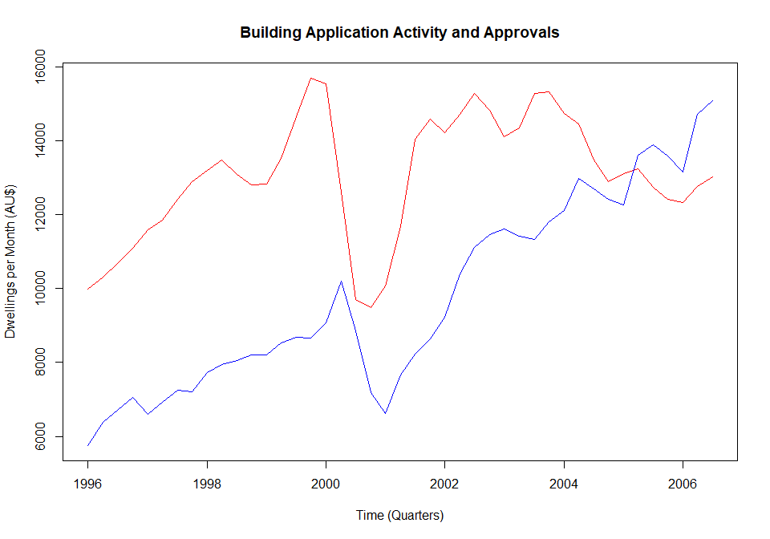

```r
Build.dat <- read.delim("~/Coding Stuff/R code/timeSeriesR/ApprovActiv.dat")

App.ts <- ts(Build.dat$Approvals, start = c(1996, 1), freq = 4)
Act.ts <- ts(Build.dat$Activity, start = c(1996, 1), freq = 4)

ts.plot(App.ts, Act.ts, col = c(2, 4), main = "Building Application Activity and Approvals", ylab ="Dwellings per Month (AU$)", xlab ="Time (Quarters)")
```

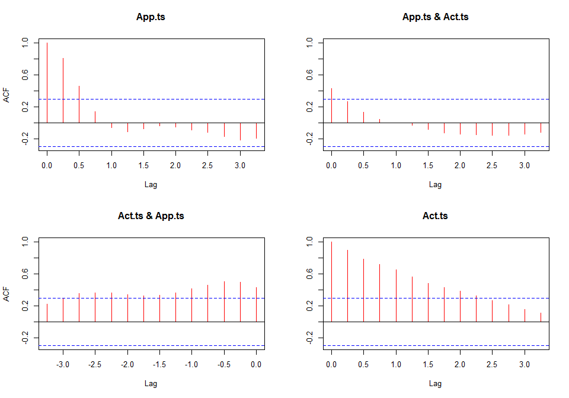

```r
# Cross Correlation
acf(ts.union(App.ts, Act.ts), col = c(2))
```

Here we can see that the building activity tends to lag one quarter behind the building approvals. The `cross-correlations function` can be used to quantify this relationship. The plot shown above, plotting cross-correlation function vs the lag is referred to as a `cross-correlogram`.

The bottom right and top left corners show the `acf` for each individual variable, while the bottom left and top right show the `ccf` for both variables for positive and negative lags. The time unit for lag in this case is one year.

If the variables are **independant**, we would expect that 5% of the sample correlations would lie outside the dashed lines. However, Several of the `cross-correlations` at negative lags do pass these lines, indicating that the **approvals time series is leading the activity**.

The `ccf` can be calculated for any two time series that overlap, however, **if the series have similar trends and seasonal effects, these will dominate**.

So lets **remove the trend and seasonal components** and try this again:

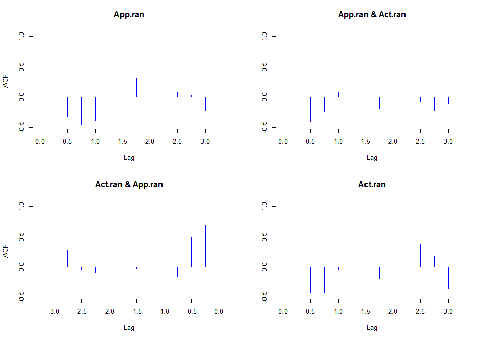

```
##
## Autocorrelations of series 'ts.union(App.ran, Act.ran)', by lag
##
## , , App.ran
##
##  App.ran        Act.ran
##   1.000 ( 0.00)  0.144 ( 0.00)
##   0.427 ( 0.25)  0.699 (-0.25)
##  -0.324 ( 0.50)  0.497 (-0.50)
##  -0.466 ( 0.75) -0.164 (-0.75)
##  -0.401 ( 1.00) -0.336 (-1.00)
##  -0.182 ( 1.25) -0.124 (-1.25)
##   0.196 ( 1.50) -0.031 (-1.50)
##   0.306 ( 1.75) -0.050 (-1.75)
##   0.078 ( 2.00) -0.002 (-2.00)
##  -0.042 ( 2.25) -0.087 (-2.25)
##   0.078 ( 2.50) -0.042 (-2.50)
##   0.027 ( 2.75)  0.272 (-2.75)
##  -0.226 ( 3.00)  0.271 (-3.00)
##  -0.216 ( 3.25) -0.147 (-3.25)
##
## , , Act.ran
##
##  App.ran        Act.ran
##   0.144 ( 0.00)  1.000 ( 0.00)
##  -0.380 ( 0.25)  0.240 ( 0.25)
##  -0.409 ( 0.50) -0.431 ( 0.50)
##  -0.247 ( 0.75) -0.419 ( 0.75)
##   0.084 ( 1.00) -0.037 ( 1.00)
##   0.346 ( 1.25)  0.211 ( 1.25)
##   0.056 ( 1.50)  0.126 ( 1.50)
##  -0.187 ( 1.75) -0.190 ( 1.75)
##   0.060 ( 2.00) -0.284 ( 2.00)
##   0.142 ( 2.25)  0.094 ( 2.25)
##  -0.080 ( 2.50)  0.378 ( 2.50)
##  -0.225 ( 2.75)  0.187 ( 2.75)
##  -0.115 ( 3.00) -0.365 ( 3.00)
##   0.161 ( 3.25) -0.278 ( 3.25)
```

```r
# Extract seasonal and trend components
App.ran <- decompose(App.ts)$random
Act.ran <- decompose(Act.ts)$random

# print the acf results
print(acf(ts.union(App.ran, Act.ran), na.action = na.pass ,col = "blue"))
```

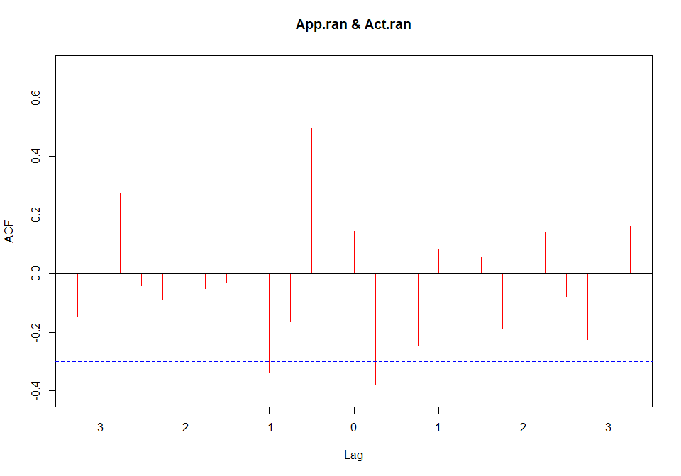

```r
# Cross correlation function
ccf(App.ran, Act.ran, na.action = na.pass, col = "red")
```

The single plot result of the `ccf` shows that there is still a lagged relationship between the activity and applications, when both the trend and seasonal effects have been removed.

## Bass Model

- Made by Frank Bass to describe the theory of adoption and diffusion of a new product by society in *Management Science*.
- The math is strightforward and the model has been influential in marketing.
- An entrepreneur with a new invention will often use the Bass model when making a case for funding.

### Model Definition

The Bass model for the number of people $N_t$, who have bought a product at time $t$ depends on three parameters:

- The total number of people who eventually buy the product ($m$)
- The **coefficient of innovation** ($p$)
- The **coefficient of imitation** ($q$)

The Bass formula is:

$$N_{t+1} = N_t + p(m- N_t) + \frac{qN_t(m-N_t)}{m}$$

According to this model, the increase in sales $N_{t+1}-N_t$, over the next time period is equal to the sum of a fixed proportion $p$ and a time varying proportion $q \frac{N_t}{m}$ of people who will buy th product but have not yet done so.

The rational for the model is that initial sales will be driven by novelty and the later sales will be driven by the fact that people have seen their friends use the product.

The model presents a difference equation. It’s solution is:

$$N_t = m \frac{1-e^{-(p+q)t}}{1+ \frac{q}{p}e^{-(p+q)t}}$$